# MatPlotLib plot típusok

Az alapok átnézése után nézzünk meg egy néhány másik plot típust is. A megfelelő plot típus kiválasztása az egyik legfontosabb lépés a plot elkészítésésnél, hiszen rengeteg nagyon jó formátum létezik, viszont mindegyiknek más az erőssége.

Ha nem tudjuk, hogy mivel induljunk inspirációnak ajánlom a következő oldalt:

https://matplotlib.org/stable/gallery/index.html

Ebben a Notebookban a leggyakrabban használt plot típusokon megyünk végig egy pár hasznos beállításukkal, de fenti linken minden verzióra található egy egyszerű példa, amiből ki lehet indulni.

```python
import matplotlib.pyplot as plt
import numpy as np
```

## Bar plot

Az oszlopdiagramot valószínűleg senkinek nem kell bemutatnom, és természetesen matplotlibben is megtalálható.

```python
caeSzabi21 = {'Január':20, 'Február':10, 'Március': 2, 'Április':4, 'Május':8, 'Június':22, 'Július':50, 'Augusztus':72, 'Szeptember':25}
honapok = list(caeSzabi21.keys())
szabik = list(caeSzabi21.values())
```

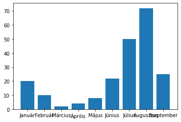

```python
plt.bar(honapok, szabik)
plt.show()
```

A `plt.tight_layout()` függvény használható arra, hogy a plot elemeit automatikusan megpróbálja úgy elrendezni, hogy jól elférjenek, de nem megoldás minden esetben.

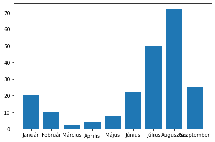

```python
plt.bar(honapok, szabik)
plt.tight_layout()
plt.show()
```

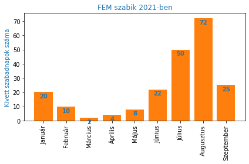

```python
fig, ax = plt.subplots()
ax.bar(honapok, szabik, color='C1')
ax.set_title("FEM szabik 2021-ben", color='C0')
ax.set_ylabel("Kivett szabadnapok száma", color='C0')
# Rotate ticks
plt.xticks(rotation = 90)
# Add labeling
for i, v in enumerate(szabik):
    ax.text(i, v + -5, str(v), color='C0', fontweight='bold', ha='center', va='bottom')
# Auto labeling added from matplotlib verison 3.4 (see ax.bar_label())
plt.tight_layout()
```

## Scatter plot

Amikor nem egy folytonos adatsort szeretnénk megjeleníteni, csak összetartozó pontpárokat, akkor a Scatter plot lehet megoldás. Használata szinte teljesen megegyezik a sima `plt.plot()`-tal, így csak röviden mutatom be.

Használata akkor a legelterjedtebb, amikor két változó közötti korrelációt szeretnénk vizualizálni, vagy esetleg kiugró értékeket ellenőriznénk.

```python
plt.style.use('seaborn')
x_dat = [5, 7, 8, 5, 6, 7, 9, 2, 3, 4, 4, 4, 2, 6, 3, 6, 8, 6, 4, 1]
y_dat = [7, 4, 3, 9, 1, 3, 2, 5, 2, 4, 8, 7, 1, 6, 4, 9, 7, 7, 5, 1]
```

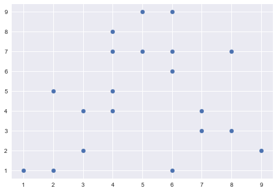

```python
plt.scatter(x_dat, y_dat)
plt.show()
```

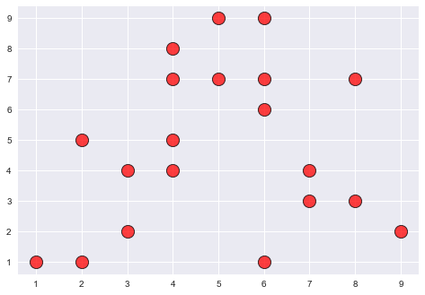

```python
plt.scatter(x_dat, y_dat, s=200, c='red', edgecolor='black', linewidth=1, alpha=0.75)
plt.show()
```

A plotunkon az x-z pontokon kívül **akár még 2 másik dimenziót** is megjeleníthetünk a markerek méretét és színét változtatva:

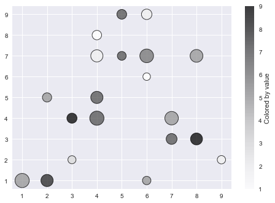

```python
colors = [7, 5, 9, 7, 5, 7, 2, 5, 3, 7, 1, 2, 8, 1, 9, 2, 5, 6, 7, 5]
sizes = [209, 486, 381, 255, 191, 315, 185, 228, 174, 538, 239, 394, 399, 153, 273, 293, 436, 501, 397, 539]
plt.scatter(x_dat, y_dat, s=sizes, c=colors, edgecolor='black', linewidth=1, alpha=0.75)  #cmap='Greens'

cBar = plt.colorbar()
cBar.set_label('Colored by value')

# Available colormaps:
# https://matplotlib.org/stable/tutorials/colors/colormaps.html
```

```python
import seaborn as sns

mpg = sns.load_dataset('mpg')
mpg['l/100km'] = 235.215 / mpg['mpg']
mpg['weight-kg'] = mpg['weight'] * 0.45359
mpg.head()
```

|  | mpg | cylinders | displacement | horsepower | weight | acceleration | model_year | origin | name | l/100km | weight-kg |
| --- | --- | --- | --- | --- | --- | --- | --- | --- | --- | --- | --- |
| 0 | 18.0 | 8 | 307.0 | 130.0 | 3504 | 12.0 | 70 | usa | chevrolet chevelle malibu | 13.067500 | 1589.37936 |
| 1 | 15.0 | 8 | 350.0 | 165.0 | 3693 | 11.5 | 70 | usa | buick skylark 320 | 15.681000 | 1675.10787 |
| 2 | 18.0 | 8 | 318.0 | 150.0 | 3436 | 11.0 | 70 | usa | plymouth satellite | 13.067500 | 1558.53524 |
| 3 | 16.0 | 8 | 304.0 | 150.0 | 3433 | 12.0 | 70 | usa | amc rebel sst | 14.700938 | 1557.17447 |
| 4 | 17.0 | 8 | 302.0 | 140.0 | 3449 | 10.5 | 70 | usa | ford torino | 13.836176 | 1564.43191 |

```python
mpg['model_year'].unique()
```

```
array([70, 71, 72, 73, 74, 75, 76, 77, 78, 79, 80, 81, 82], dtype=int64)
```

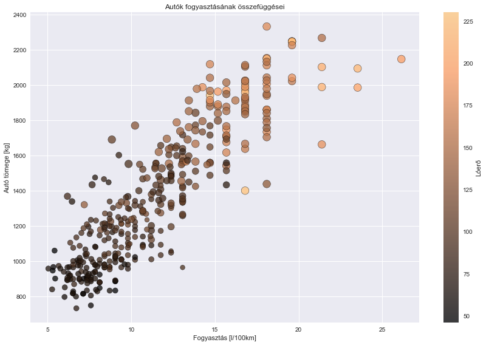

```python
fig, ax = plt.subplots(figsize=(12,8))

mpgPlot = ax.scatter(mpg['l/100km'], mpg['weight-kg'], alpha=0.75, edgecolor='black', linewidth=0.5,
                     c=mpg['horsepower'], cmap='copper', s=mpg['cylinders']*20)
ax.set_xlabel('Fogyasztás [l/100km]')
ax.set_ylabel('Autó tömege [kg]')
ax.set_title('Autók fogyasztásának összefüggései')
cBar = fig.colorbar(mpgPlot)
cBar.set_label('Lóerő')
plt.tight_layout()
```

## Boxplot - Violinplot

A box és violin plot kategorizált adatok eloszlását mutatja. Segítségükkel jól összehasonlíthatóak a különböző kategóriák. A boxplot a kvartilisek elhelyezkedését jeleníti meg, a violinplot pedig az egész eloszlásról ad infomációt.

```python
np.sort(mpg['cylinders'].unique())
```

```
array([3, 4, 5, 6, 8], dtype=int64)
```

```python
cylinders = np.sort(mpg['cylinders'].unique())
data = [mpg[mpg['cylinders']==cylinder]['l/100km'] for cylinder in cylinders]
```

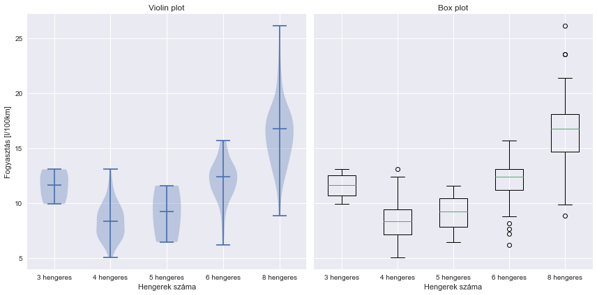

```python
fig, axs = plt.subplots(nrows=1, ncols=2, figsize=(12, 6), sharey=True)

# plot violin plot
axs[0].violinplot(data, showmeans=False, showmedians=True)
axs[0].set_title('Violin plot')
axs[0].set_ylabel('Fogyasztás [l/100km]')

# plot box plot
axs[1].boxplot(data)
axs[1].set_title('Box plot')

# add x-tick labels
plt.setp(axs, xticks=[y + 1 for y in range(len(data))],
         xticklabels=[f'{cylinder} hengeres' for cylinder in cylinders],
         xlabel='Hengerek száma')
plt.tight_layout()
plt.show()
```

Figyelni kell azonban az egyes kategóriákba sorolt elemek számára:

```python
labels, counter = [], []
for dat, henger in zip(data, cylinders):
    print(f'A {henger} hengeres autókból {len(dat)} darab volt.')
    labels.append(f'{henger} hengeres')
    counter.append(len(dat))
```

```
A 3 hengeres autókból 4 darab volt.
A 4 hengeres autókból 204 darab volt.
A 5 hengeres autókból 3 darab volt.
A 6 hengeres autókból 84 darab volt.
A 8 hengeres autókból 103 darab volt.
```

## Pie chart

A kördiagram nem tipikusan a mérnöki szakmának a legelterjedtebb plot típusa, de bizonyos adatok megjelenítéséhez előnyös lehet.

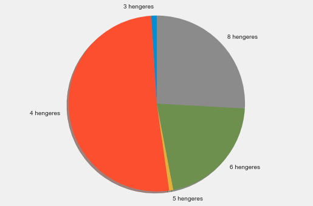

```python
plt.style.use("fivethirtyeight")

# Pie chart, where the slices will be ordered and plotted counter-clockwise:

fig, ax = plt.subplots()
ax.pie(counter, labels=labels,shadow=True, startangle=90)
ax.axis('equal')  # Equal aspect ratio ensures that pie is drawn as a circle.

plt.show()
```

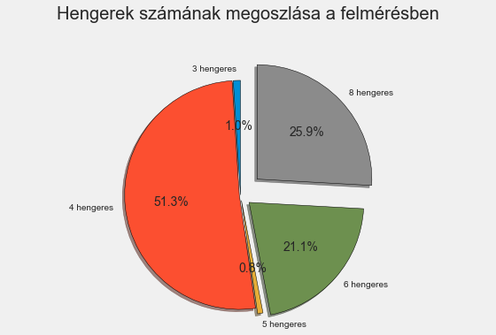

```python
# Százalékos felirat, kiemelt cím, explode.

fig, ax = plt.subplots()
ax.pie(counter, labels=labels, shadow=True, startangle=90,
       autopct='%1.1f%%', explode=[0, 0.01, 0.05, 0.1, 0.2], wedgeprops={'edgecolor': 'black'})
ax.axis('equal')
ax.set_title('Hengerek számának megoszlása a felmérésben', y=1.1) # Move the title higher
plt.tight_layout()
plt.show()
```

## Időjelek megjelenítése

```python
import pandas as pd
df = pd.read_csv('src/covid_impact_on_airport_traffic.csv')
df['Date'] = pd.to_datetime(df.Date)
df.sort_values(by='Date', inplace=True)
df.head()
```

|  | AggregationMethod | Date | Version | AirportName | PercentOfBaseline | Centroid | City | State | ISO_3166_2 | Country | Geography |
| --- | --- | --- | --- | --- | --- | --- | --- | --- | --- | --- | --- |
| 302 | Daily | 2020-03-16 | 1.0 | Santiago International Airport | 96 | POINT(-70.7942372739446 -33.3907265266744) | Santiago | Santiago Province | CL | Chile | POLYGON((-70.8043956756592 -33.3719683869737, ... |
| 1713 | Daily | 2020-03-16 | 1.0 | Halifax International | 72 | POINT(-63.5116720134583 44.8830168353507) | Halifax | Nova Scotia | CA-NS | Canada | POLYGON((-63.5266613960266 44.8984438169036, -... |
| 3963 | Daily | 2020-03-16 | 1.0 | Hartsfield-Jackson Atlanta International | 92 | POINT(-84.4279188822754 33.6410758198944) | College Park | Georgia | US-GA | United States of America (the) | POLYGON((-84.4299745559692 33.657852680999, -8... |
| 2989 | Daily | 2020-03-16 | 1.0 | Los Angeles International | 98 | POINT(-118.404993180627 33.941369379328) | Los Angeles | California | US-CA | United States of America (the) | POLYGON((-118.439612388611 33.9517616366508, -... |
| 5701 | Daily | 2020-03-16 | 1.0 | McCarran International | 68 | POINT(-115.14888081287 36.082853976328) | Paradise | Nevada | US-NV | United States of America (the) | POLYGON((-115.158487558365 36.1007120735771, -... |

```python
df.AirportName.unique()
```

```
array(['Santiago International Airport', 'Halifax International',
       'Hartsfield-Jackson Atlanta International ',
       'Los Angeles International', 'McCarran International',
       'Charlotte Douglas International', 'Chicago OHare International',
       'Edmonton International', 'Washington Dulles International ',
       'Seattle-Tacoma International ', 'Montreal Mirabel',
       'Vancouver International', 'Daniel K. Inouye International ',
       'John F. Kennedy International', 'Miami International ',
       'San Francisco International', 'LaGuardia',
       'Dallas/Fort Worth International ',
       'Newark Liberty International ', 'Kingsford Smith',
       'Montreal Trudeau', 'Detroit Metropolitan Wayne County ',
       'Hamilton International', 'Denver International',
       'Toronto Pearson', 'Winnipeg International',
       'Boston Logan International ', 'Calgary International'],
      dtype=object)
```

```python
dates = df['Date'].unique()
JFK = df[df['AirportName']=='John F. Kennedy International']['PercentOfBaseline']
LAX = df[df['AirportName']=='Los Angeles International']['PercentOfBaseline']
```

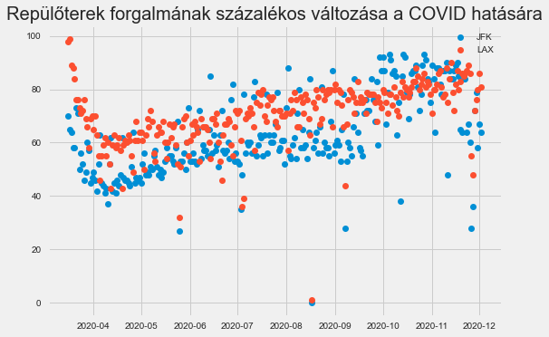

```python
fig, ax = plt.subplots()

ax.plot_date(dates, JFK, label='JFK') #, ls='-'
ax.plot_date(dates, LAX, label='LAX')
ax.legend()
ax.set_title('Repülőterek forgalmának százalékos változása a COVID hatására')
plt.show()
```